# TP Introduction To Extreme Value Theory

BERGUIGA Oussama

March 22,2018

# 1 Introduction

The main purpose of that project is to use main results of the Extreme Value Theory on different data sets (portpirie, dow jones and glass)

## 1.1 Packages loading

```r
setwd('C:\\Users\\oussa\\Downloads\\Data Science\\Master Statistique Big Data Dauphine\\Module 2\\Valeurs Extremes')
library(evir)
library(ismev)
library(fitdistrplus)
library(fExtremes)
```

# 2 Study of PORTPIRIE Data Set

In that dataset we find annual maximum sea levels recorded at Port Pirie, in South Australia

```r
data(portpirie)
?portpirie
```

```
## starting httpd help server ... done
```

## 2.1 Descriptive Statistics

```r
nrow(portpirie)
```

```
## [1] 65
```

```r
summary(portpirie$SeaLevel)
```

```
##    Min. 1st Qu.  Median    Mean 3rd Qu.    Max.
##   3.570   3.830   3.960   3.981   4.110   4.690
```

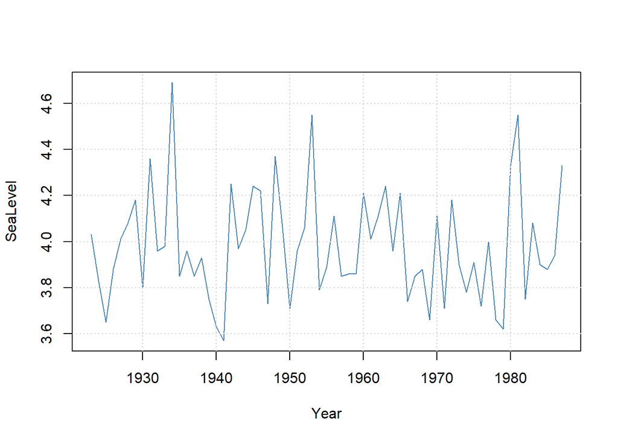

```r
plot(portpirie,type="l",col="steelblue")

grid()
```

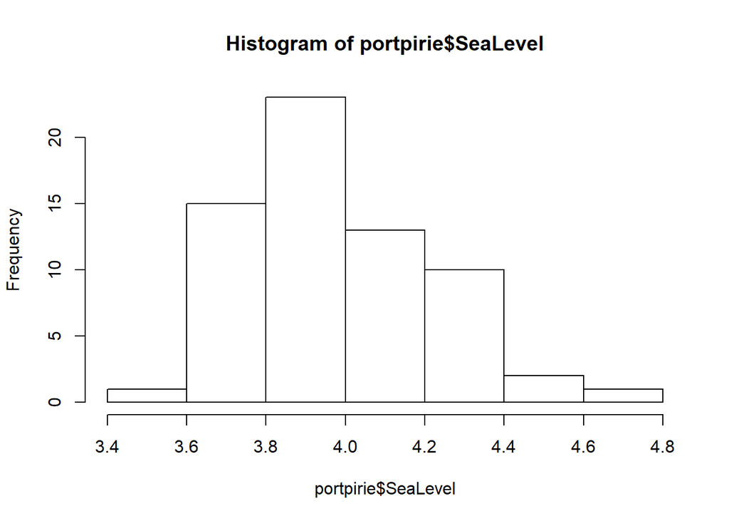

```r
hist(portpirie$SeaLevel)
```

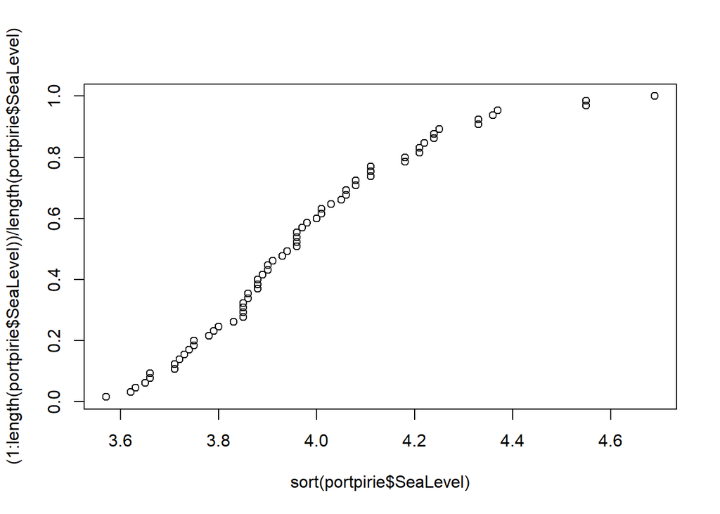

```r
plot(sort(portpirie$SeaLevel),(1:length(portpirie$SeaLevel))
     /length(portpirie$SeaLevel))
```

Most of the sea levels maximum are around 4 meters, the maximum of the maximums is around 4.7 meters

## 2.2 Choice of modelisation

Let us try a GEV model for the portpirie case

## 2.3 Choice of the blocs

We already have the annual maximum of porpotries SeaLevel,here we have no choice, so it is annual blocks, which is a good pragmatic option.

## 2.4 Estimation of the parameters

First we try a gevfit

```r
fitmle_gev_portpirie1=gevFit(portpirie$SeaLevel,type="mle",block=1)

fitmle_gev_portpirie1
```

```
##
## Title:
##  GEV Parameter Estimation
##
## Call:
##  gevFit(x = portpirie$SeaLevel, block = 1, type = "mle")
##
## Estimation Type:
##   gev mle
##
## Estimated Parameters:
##          xi          mu        beta
## -0.05013639  3.87475503  0.19804734
##
## Description
##   Thu Mar 22 22:25:16 2018
```

```r
#gamma=-0.05 b=3.87 a = 0.2

#Weibull attraction domain
```

```r
fitmle_gev_portpirie2=gev.fit(portpirie$SeaLevel)
```

```
## $conv
## [1] 0
##
## $nllh
## [1] -4.339058
##
## $mle
## [1]  3.87474692  0.19804120 -0.05008773
##
## $se
## [1] 0.02793211 0.02024610 0.09825633
```

```r
fitmle_gev_portpirie2
```

```
## $trans
## [1] FALSE
##
## $model
## $model[[1]]
## NULL
##
## $model[[2]]
## NULL
##
## $model[[3]]
## NULL
##
##
## $link
```

[output cut: 97 more lines]

```r
# b = 3.87474692  a = 0.19804120 gamma = -0.05008773


#95% confidence intervalfor gamma:

IC=c(-0.05008773-0.09825633*2/sqrt(65),-0.05008773+0.09825633*2/sqrt(65))
IC
```

```
## [1] -0.07446213 -0.02571333
```

```r
#0 does not seem to be part of the confidence interval
```

Let us try the probability weigthed moments method (better if we do not have enough data)

```r
fitpwrgev_portprie = gevFit(portpirie$SeaLevel,type="pwm")
fitpwrgev_portprie
```

```
##
## Title:
##  GEV Parameter Estimation
##
## Call:
##  gevFit(x = portpirie$SeaLevel, type = "pwm")
##
## Estimation Type:
##   gev pwm
##
## Estimated Parameters:
##          xi          mu        beta
## -0.05119127  3.87314570  0.20321876
##
## Description
##   Thu Mar 22 22:25:16 2018
```

```r
#results are clothes to those with Maximum Likelihood Estimator
```

Let us try a Gumbel modelisation

```r
fitmle_gumbel_portpirie1=gumbelFit(portpirie$SeaLevel,type=c("mle"))

fitmle_gumbel_portpirie1
```

```
##
## Title:
##  Gumbel Parameter Estimation
##
## Call:
##  gumbelFit(x = portpirie$SeaLevel, type = c("mle"))
##
## Estimation Type:
##   gum mle
##
## Estimated Parameters:
##        mu      beta
## 3.8694924 0.1948879
##
## Description
##   Thu Mar 22 22:25:16 2018
```

```r
fitmle_gumbel_portpirie2=gum.fit(portpirie$SeaLevel,type=c("pwm"))
```

```
## $conv
## [1] 0
##
## $nllh
## [1] -4.217682
##
## $mle
## [1] 3.8694426 0.1948867
##
## $se
## [1] 0.02549356 0.01885190
```

```r
fitmle_gumbel_portpirie2
```

```
## $trans
## [1] FALSE
##
## $model
## $model[[1]]
## NULL
##
## $model[[2]]
## NULL
##
##
## $link
## [1] "identity" "identity"
##
## $conv
```

[output cut: 93 more lines]

```r
# b = 3.8694426  a = 0.1948867
```

## 2.5 Probability ,Quantile and return level plots interpretation

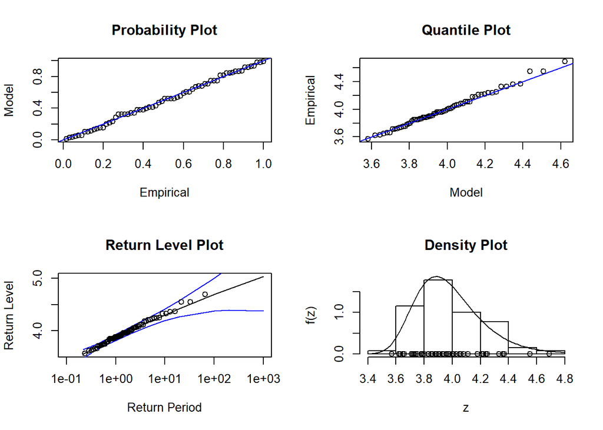

```r
gev.diag(fitmle_gev_portpirie2)
```

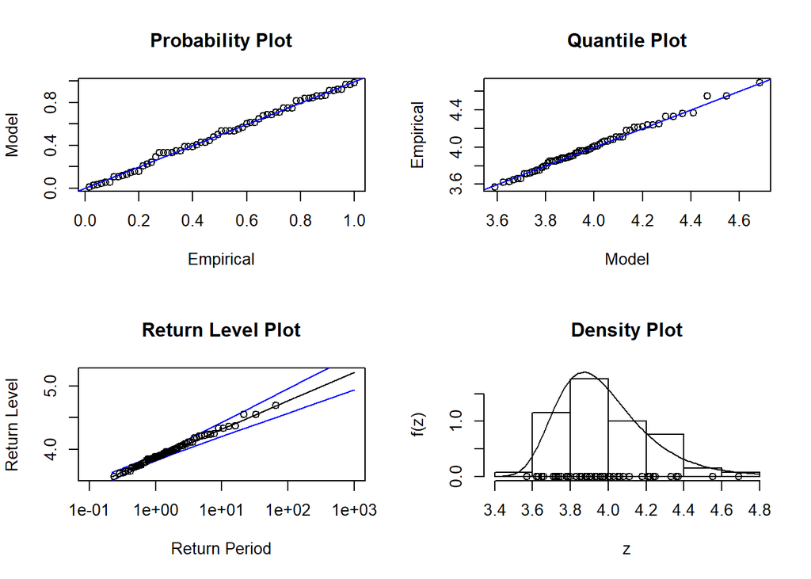

```r
gum.diag((fitmle_gumbel_portpirie2))
```

In view of the QQplots and the Probability plots, it seems that both Gumbel and Weibull modelisation are a good fit. But we can notice that the confidence interval for the return level plot is better for the Gumbel fit than for the Weibull model.Moreover with Gumbel we have less parameters, then with that parcimony principle, I prefer to choose Gumbel modelisation.

Moreover the Gumbel return Level plot is a linear function which is consistent with what we saw in the lesson.

## 2.6 Maximum domain of attraction

The maximum domain of attraction is Gumbel with gamma =0

## 2.7 Estimation of a return level corresponding to a return period 100 and 1000 or endpoint

```r
xi=0
mu=3.8694924
beta= 0.1948879


#model Gumbel
#return level plot


fExtremes::qgev(1/100,xi=0,mu=mu,beta=beta,lower.tail=FALSE)
```

```
## [1] 4.766006
## attr(,"control")
##  xi       mu      beta lower.tail
##   0 3.869492 0.1948879      FALSE
```

```r
#maximum sea level for the next 100 years : 4.77 meters

fExtremes::qgev(1/1000,xi=xi,mu=mu,beta=beta,lower.tail=FALSE)
```

```
## [1] 5.215633
## attr(,"control")
##  xi       mu      beta lower.tail
##   0 3.869492 0.1948879      FALSE
```

```r
#maximum sea level for the next 1000 years : 5.22 meters
```

## 2.8 Small conclusion

With a Gumbel model we could estimate that the maximum sea level of Port Pirie in a 100 and 1000 years are respectively around 4.77 and 5.22 meters,with a good confidence interval.It means that once every 100 years (respectively 1000 years) the PortPirie Sea Level annual maximum is above 4.77 meters (respectively 5.22 meters). Those results are consistent with the data since the maximum level in the past data is 4.69 meters.

# 3 Study of DowJones DataSet

## 3.1 Descriptive Statistics

In the DowJones dataset there are daily closing prices of the Dow Jones Index over the period 1996 to 2000

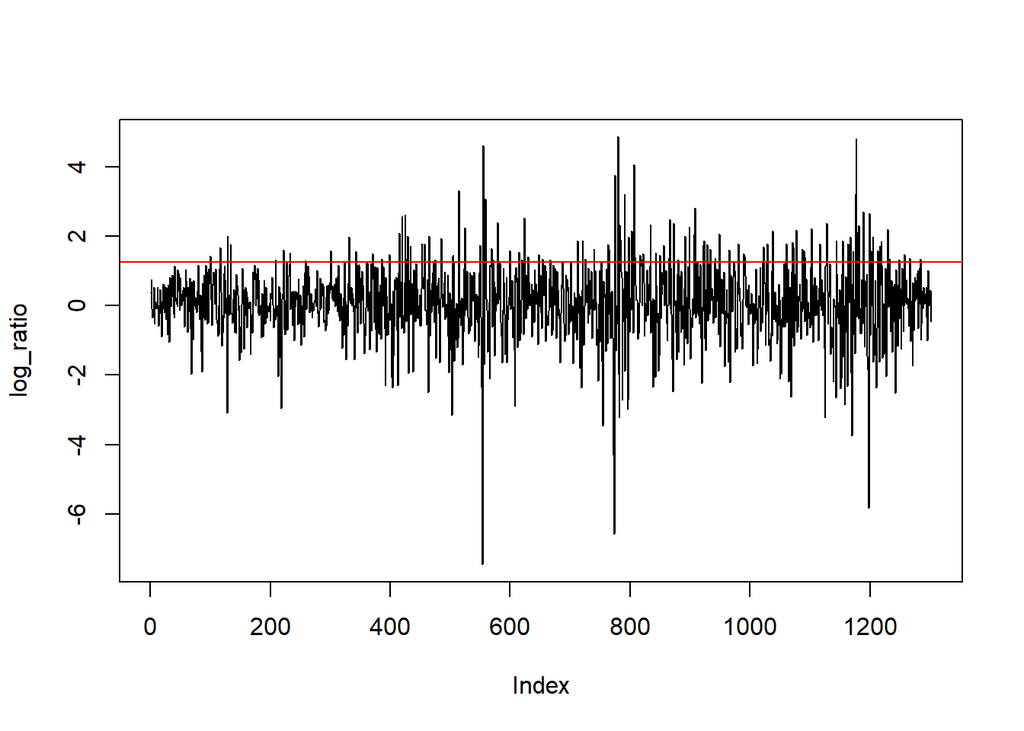

```r
data(dowjones)
?dowjones


log_ratio=100*diff(log(dowjones$Index))[-1]

plot(log_ratio,type="l")
abline(h=1.25,col='red')#we will see later that the red line corresponds to a fixed optimal threshold of 1.25 "log-$"
```

```r
summary(log_ratio)
```

```
##     Min.  1st Qu.   Median     Mean  3rd Qu.     Max.
## -7.45500 -0.47790  0.05287  0.06634  0.67700  4.86100
```

The log ratios are between -7.5 and 4.9 with a mean and a median around 0.06

Here we have daily data let us try a GPD model

## 3.2 Choice of the thresholds

POT Method: We need the threshold to be close enough to the maximum (Pickand’s theorem) but not too close (variance bias balance).

```r
findthresh(log_ratio,c(1,10,100))
```

```
## [1] 4.809520 2.709723 1.397623
```

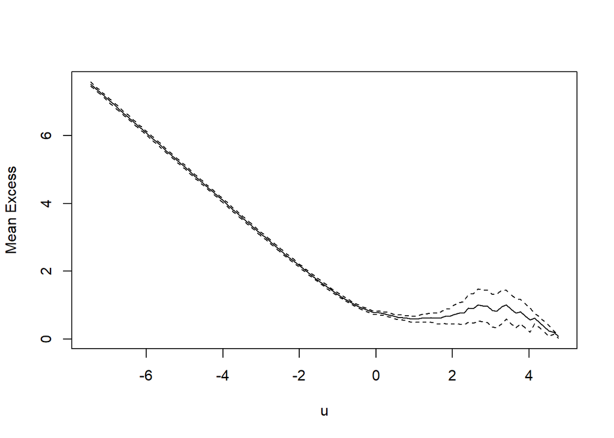

```r
mrl.plot(log_ratio)
```

The Mean Excess has to be linear with u at levels of u for which the Generalized Pareto model is appropriate. Based on the previous graphics, we can see that the linear tendancy ends for u between 0 and 2. Let us look for the confidence interval for $\sigma$ (scale) and $\gamma$ (shape) :

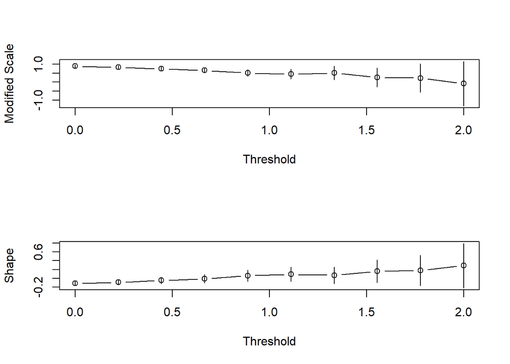

```r
?gpd.fitrange
gpd.fitrange(log_ratio,0,2)
```

Thanks to that graphical method, it seems that 1.25 is a good threshold (we have a constant shape around 0 and the length of confidence intervals are low)

```r
threshold=1.25
log_ratio_excess=log_ratio[log_ratio>threshold]
log_ratio_excess
```

```
##   [1] 1.426725 1.662865 2.000709 1.750577 1.323736 1.610578 1.509264
##   [8] 1.298631 1.574890 1.276691 1.979252 1.564724 1.263899 1.498175
##  [15] 1.349871 1.465522 2.074764 1.397623 2.569914 2.604867 1.348571
##  [22] 2.006131 1.704060 1.770474 1.774591 2.002369 1.280099 1.312468
##  [29] 1.940522 1.402783 1.459687 1.294050 3.320608 2.238415 1.739514
##  [36] 4.600841 3.073843 1.646851 1.310130 2.399422 1.462048 1.573205
##  [43] 1.530362 1.315576 1.276387 2.513889 1.397074 1.470134 1.343216
##  [50] 1.325365 1.282023 1.866790 1.876847 1.337908 1.628343 1.763002
##  [57] 1.617202 3.753540 4.860535 2.335575 1.904021 3.205062 1.973961
##  [64] 2.144608 1.282328 4.064700 1.404655 1.459207 1.318650 1.495400
##  [71] 2.317165 1.525078 1.457880 1.727170 1.372466 2.479741 2.379336
##  [78] 1.308964 2.008075 2.252084 2.043684 2.798425 1.266903 1.738730
##  [85] 1.861366 1.762358 1.615276 1.263642 1.368107 2.069903 1.610815
##  [92] 1.268681 1.777040 1.492308 1.427078 1.693370 1.778142 2.146270
##  [99] 1.789086 1.820096 1.661830 2.166288 1.628992 1.581920 1.392526
## [106] 2.213819 1.788511 2.364810 1.860344 1.866997 1.774151 1.970440
## [113] 1.552234 3.211285 4.809520 2.104159 2.302963 2.709723 2.649965
## [120] 1.732132 1.571667 1.985640 1.575805 1.704088 1.852773 2.188660
## [127] 1.329531 1.319780 1.463366 1.372262 1.336179
```

```r
length(log_ratio_excess)/length(log_ratio)
```

```
## [1] 0.1006144
```

```r
#10 % of the data are above the excess
```

## 3.3 Estimation of the parameters

First we can use the probably weighted moment method

```r
gpdfit3=gpdFit(log_ratio,u=threshold,type="pwm")
gpdfit3
```

```
##
## Title:
##   GPD Parameter Estimation
##
## Call:
##  gpdFit(x = log_ratio, u = threshold, type = "pwm")
##
## Estimation Method:
##   gpd pwm
##
## Estimated Parameters:
##         xi       beta
## 0.07405389 0.57480697
##
## Description
##   Thu Mar 22 22:25:22 2018 by user: oussa
```

```r
#gamma=0.07405389 sigma=0.57480697
```

But as we have a lot of data here we can prefere the MLE method

```r
gpdfit1=gpd.fit(log_ratio,threshold)
```

```
## $threshold
## [1] 1.25
##
## $nexc
## [1] 131
##
## $conv
## [1] 0
##
## $nllh
## [1] 68.02454
##
## $mle
## [1] 0.56689410 0.08680442
##
## $rate
## [1] 0.1006144
##
## $se
## [1] 0.07234195 0.09332016
```

```r
gpdfit2=gpdFit(log_ratio,u=threshold,type="mle")
gpdfit2
```

```
##
## Title:
##   GPD Parameter Estimation
##
## Call:
##  gpdFit(x = log_ratio, u = threshold, type = "mle")
##
## Estimation Method:
##   gpd mle
##
## Estimated Parameters:
##         xi       beta
## 0.08680205 0.56688864
##
## Description
##   Thu Mar 22 22:25:23 2018 by user: oussa
```

## 3.4 Maximum domain of attraction

Since gamma is approximatively equal to 0.087 > 0 this corresponds to a Frechet domain of attraction in the GEV theory. Then the distribution of excesses has no upper limit

```r
gamma=0.08680205
sigma=0.56688864
```

## 3.5 Probability, Quantile and Return level plots and interpretation

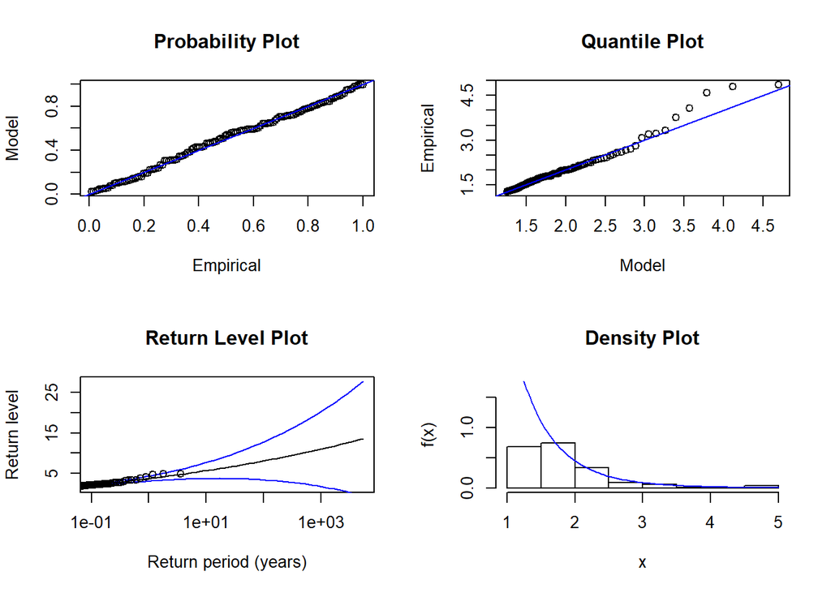

```r
gpd.diag(gpdfit1)
```

The probability plot is very good

The confidence interval in the return level plot seems to be good until T=1e1. Yet we have some few points out of the Quantile Plot (in the tail of the distribution) Moreover since gamma > 0 we can see convexity in the Return Level Plot

## 3.6 Estimation of a return level corresponding to a return period 100 and 1000 or endpoint

```r
#1304 data from 1996 to 2000 means :
1304/5
```

```
## [1] 260.8
```

```r
#261 datas a year

?gpdTailPlot
tail.mle=gpdTailPlot(gpdfit2)
gpdRiskMeasures(gpdfit2,p=1-1/(100*1304/5))# 7.65
```

```
##              p quantile shortfall
## beta 0.9999617 7.653428  8.882864
```

```r
gpdRiskMeasures(gpdfit2,p=1-1/(1000*1304/5))# 10.51
```

```
##              p quantile shortfall
## beta 0.9999962 10.51504  12.01648
```

```r
gpdQPlot(tail.mle,p=1-1/(100*1304/5),ci=0.95)
```

```
## Lower CI Estimate Upper CI
## 5.247828 7.653428 7.290802
```

[figure not shown]

```
##  Lower CI  Estimate  Upper CI
##  6.114939 10.515038  7.290802
```

```r
gpdQPlot(tail.mle,p=1-1/(1000*1304/5),ci=0.95)
```

# 4 Study of Glass DataSet

The glass dataset contains breaking strength of 63 glass fibres of length 1.5 centimeters

```r
?glass
data(glass)
summary(glass)
```

```
##    Min. 1st Qu.  Median    Mean 3rd Qu.    Max.
##   0.550   1.375   1.590   1.507   1.685   2.240
```

Here we want to study the minimum strength to break the glass.Let X1,X2,..Xn be the strengths, then the minimum of the serie is - (the maximum of (-X1,…,-Xn)

## 4.1 Descriptive Statistics

```r
moins_glass=(-1)*(glass)




nrow(moins_glass)
```

[output not shown]

```r
summary(moins_glass)
```

```
##    Min. 1st Qu.  Median    Mean 3rd Qu.    Max.
##  -2.240  -1.685  -1.590  -1.507  -1.375  -0.550
```

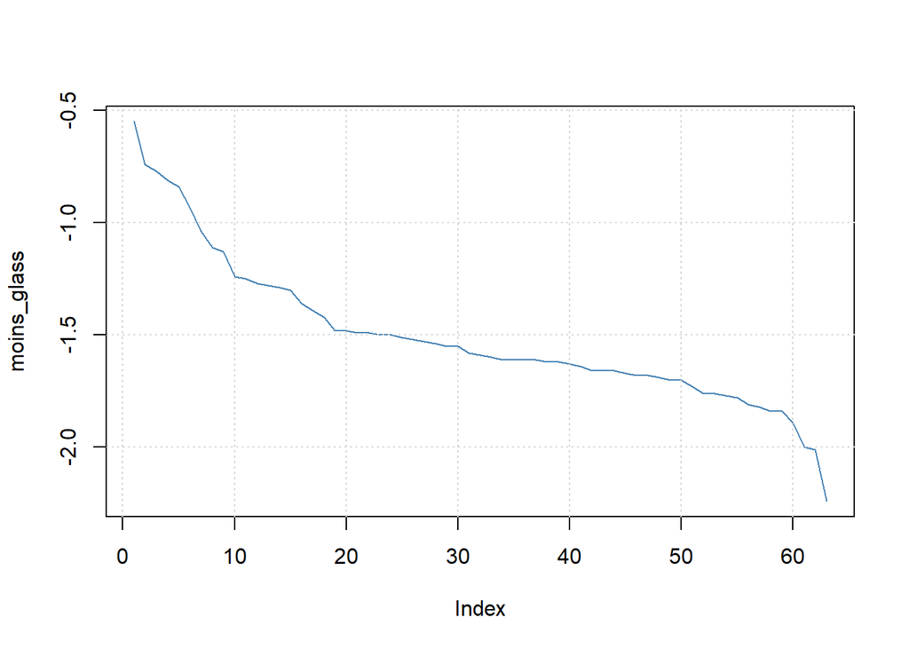

```r
plot(moins_glass,type="l",col="steelblue")

grid()
```

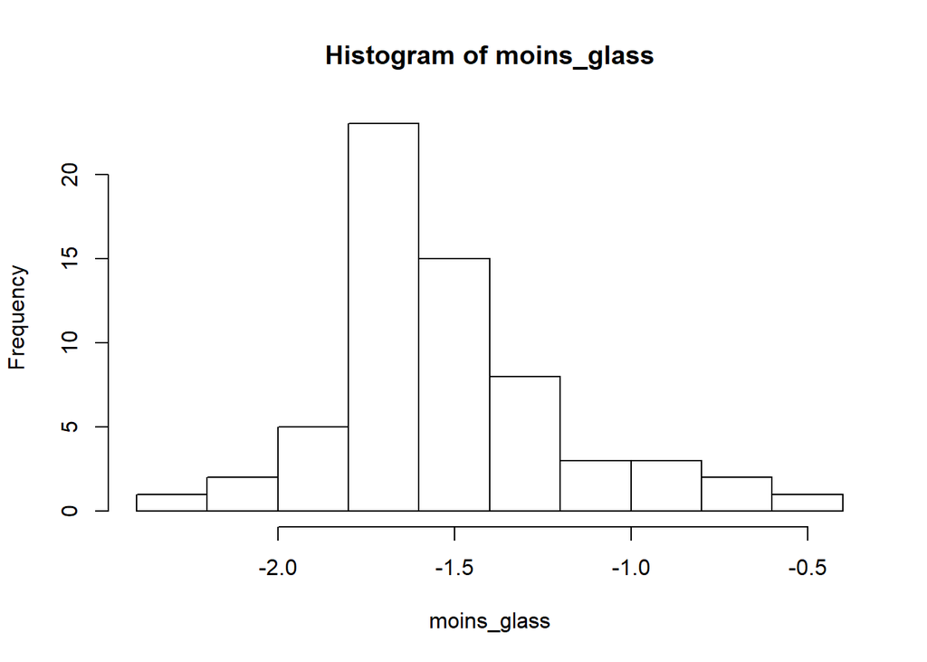

```r
hist(moins_glass)
```

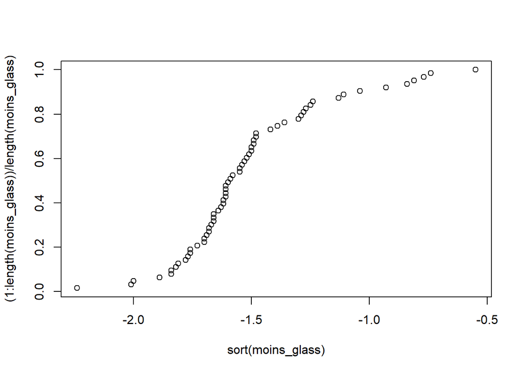

```r
plot(sort(moins_glass),(1:length(moins_glass))
     /length(moins_glass))
```

```r
#most of the maximums are between -1.5 and -2
```